# Segmenter Version Comparison

This notebook calculates and visualizes key segment metrics to allow the user to compare a new pipeline to the old one for QA purposes. This was specifically built to compate pipe 3 to pipe 2.5 and is not guaranteed when using different pipeline versions. Even using a new version of pipe 3 may require some changes if column names have changed.

Author: Jenn Van Osdel  
Last Updated: August 24, 2022

```python
import os
import pandas as pd
import matplotlib.pyplot as plt
import pyseas.maps as psm
import pyseas.contrib as psc

from config import DATASET_OLD, DATASET_NEW_MONTHLY_INT, FRAGMENTS_TABLE, SEGMENTS_TABLE, MESSAGES_SEGMENTED_TABLE, SEGMENT_INFO_TABLE

pd.set_option("max_rows", 20)
```

## Data generation

*NOTE: this query is not fully flexible on dates and still assumes all data is within 2020 as hardcoding "2020" into the table suffix decreased query costs by ~95%. You may need to modify the query and check costs if running a period outside of 2020.*

```python
def make_daily(df):
    df_daily = df.copy().groupby(['date', 'year']).sum().reset_index()
    df_daily['avg_seg_length_h_new'] = df_daily.sum_seg_length_h_new / df_daily.num_segs_distinct_new
    df_daily['avg_seg_length_h_old'] = df_daily.sum_seg_length_h_old / df_daily.num_segs_distinct_old
    df_daily['avg_seg_length_h_diff'] = df_daily.avg_seg_length_h_new - df_daily.avg_seg_length_h_old
    return df_daily
```

```python
q = f'''
CREATE TEMP FUNCTION start_date() AS (
  (SELECT DATE(PARSE_TIMESTAMP("%Y%m%d", MIN(_TABLE_SUFFIX)))
  FROM `{DATASET_NEW_MONTHLY_INT}.{SEGMENTS_TABLE}*`)
);

CREATE TEMP FUNCTION end_date() AS (
  (SELECT DATE(PARSE_TIMESTAMP("%Y%m%d", MAX(_TABLE_SUFFIX)))
  FROM `{DATASET_NEW_MONTHLY_INT}.{SEGMENTS_TABLE}*`)
);

WITH

segment_data_new AS (
    SELECT
    DATE(seg.timestamp) AS date,
    EXTRACT(YEAR from DATE(seg.timestamp)) AS year,
    seg.ssvid AS ssvid,
    COUNT(*) AS num_segs,
    COUNT(DISTINCT seg_id) AS num_segs_distinct,
    SUM(TIMESTAMP_DIFF(frag.last_msg_timestamp, seg.first_timestamp, MINUTE)/60.0) AS sum_seg_length_h,
    SUM(TIMESTAMP_DIFF(frag.last_msg_timestamp, frag.first_msg_timestamp, MINUTE)/60.0) AS sum_seg_day_length_h,
    FROM `{DATASET_NEW_MONTHLY_INT}.{SEGMENTS_TABLE}*` seg
    JOIN `{DATASET_NEW_MONTHLY_INT}.{FRAGMENTS_TABLE}*` frag
    USING(frag_id)
    GROUP BY date, year, ssvid
),

segment_data_old AS (
      SELECT
    DATE(timestamp) as date,
    EXTRACT(YEAR from DATE(timestamp)) as year,
    ssvid,
    COUNT(*) AS num_segs,
    COUNT(DISTINCT seg_id) AS num_segs_distinct,
    SUM(TIMESTAMP_DIFF(last_msg_of_day_timestamp, IF(DATE(first_msg_timestamp) >= start_date(), first_msg_timestamp, TIMESTAMP(start_date())), MINUTE)/60.0) as sum_seg_length_h,
    SUM(TIMESTAMP_DIFF(last_msg_of_day_timestamp, first_msg_of_day_timestamp, MINUTE)/60.0) AS sum_seg_day_length_h,
    FROM `{DATASET_OLD}.{SEGMENTS_TABLE}2020*`
    WHERE ssvid IN (SELECT DISTINCT ssvid FROM `{DATASET_NEW_MONTHLY_INT}.{SEGMENTS_TABLE}*`)
    AND _TABLE_SUFFIX BETWEEN FORMAT_TIMESTAMP("%m%d", start_date()) AND FORMAT_TIMESTAMP("%m%d", end_date())
    -- Necessary to filter out segments that have had no positions in 2020
    -- but have not yet closed because a new position isn't reported for
    -- that MMSI for days/weeks/months.
    AND first_msg_of_day_timestamp IS NOT NULL
    GROUP BY date, year, ssvid
),

segment_join AS (
    SELECT
    date,
    year,
    ssvid,
    IFNULL(segs_new.num_segs, 0) AS num_segs_new,
    IFNULL(segs_new.num_segs_distinct, 0) AS num_segs_distinct_new,
    IFNULL(segs_new.sum_seg_length_h, 0) AS sum_seg_length_h_new,
    IFNULL(segs_new.sum_seg_day_length_h, 0) AS sum_seg_day_length_h_new,
    IFNULL(segs_old.num_segs, 0) AS num_segs_old,
    IFNULL(segs_old.num_segs_distinct, 0) AS num_segs_distinct_old,
    IFNULL(segs_old.sum_seg_length_h, 0) AS sum_seg_length_h_old,
    IFNULL(segs_old.sum_seg_day_length_h, 0) AS sum_seg_day_length_h_old,
    FROM segment_data_new segs_new
    FULL OUTER JOIN segment_data_old segs_old
    USING(date, year, ssvid)
    ORDER BY ssvid, date
)

SELECT
date,
year,
ssvid,
num_segs_new,
num_segs_distinct_new,
sum_seg_length_h_new,
sum_seg_day_length_h_new,
num_segs_old,
num_segs_distinct_old,
sum_seg_length_h_old,
sum_seg_day_length_h_old,
(num_segs_new - num_segs_old) as num_segs_diff,
(num_segs_distinct_new - num_segs_distinct_old) as num_segs_distinct_diff,
(sum_seg_length_h_new - sum_seg_length_h_old) as sum_seg_length_h_diff,
(sum_seg_day_length_h_new - sum_seg_day_length_h_old) as sum_seg_day_length_h_diff,
FROM segment_join
'''

# print(q)
df_segs_daily_by_ssvid = pd.read_gbq(q, project_id='world-fishing-827', dialect='standard')

df_segs_daily = make_daily(df_segs_daily_by_ssvid)

# Quick checks for duplicate seg_id
assert(df_segs_daily_by_ssvid[df_segs_daily_by_ssvid.num_segs_new != df_segs_daily_by_ssvid.num_segs_distinct_new].shape[0] == 0)
assert(df_segs_daily[df_segs_daily.num_segs_new != df_segs_daily.num_segs_distinct_new].shape[0] == 0)
```

```python
def plot_new_vs_old(df, col_prefix, title, ylabel=""):
    fig = plt.figure()
    ax = df[[f'{col_prefix}old']].plot(label='old')
    df[[f'{col_prefix}new']].plot(label='new', ax=ax)
    years = list(df.year.sort_values().unique())
    ax.set_xticks([t*365 for t in range(len(years))])
    ax.set_xticklabels(years)
    fig.patch.set_facecolor('white')
    plt.legend()
    plt.title(title)
    plt.ylabel(ylabel)
    return fig, ax
```

```python
def plot_diff(df, col_prefix, title, ylabel=""):
    fig = plt.figure()
    ax = df[[f'{col_prefix}diff']].plot(c='green', label='diff')
    years = list(df.year.sort_values().unique())
    ax.set_xticks([t*365 for t in range(len(years))])
    ax.set_xticklabels(years)
    fig.patch.set_facecolor('white')
    plt.legend()
    plt.title(title)
    plt.ylabel(ylabel)
    return fig, ax
```

## Daily Stats

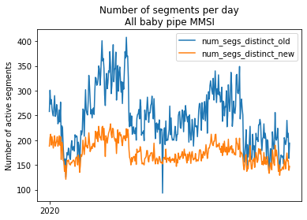

```python
fig = plot_new_vs_old(df_segs_daily, col_prefix='num_segs_distinct_',
                      title="Number of segments per day\nAll baby pipe MMSI",
                      ylabel="Number of active segments")
```

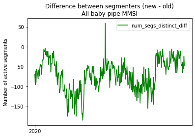

```python
fig = plot_diff(df_segs_daily, col_prefix='num_segs_distinct_',
                title="Difference between segmenters (new - old)\nAll baby pipe MMSI",
                ylabel="Number of active segments")
```

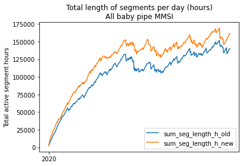

```python
fig = plot_new_vs_old(df_segs_daily, col_prefix='sum_seg_length_h_',
                      title="Total length of segments per day (hours)\nAll baby pipe MMSI",
                      ylabel="Total active segment hours")
```

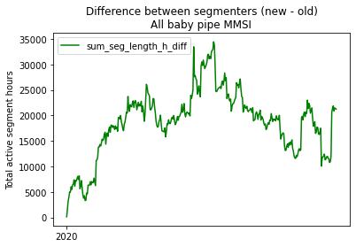

```python
fig = plot_diff(df_segs_daily, col_prefix='sum_seg_length_h_',
                title="Difference between segmenters (new - old)\nAll baby pipe MMSI",
                ylabel="Total active segment hours")
```

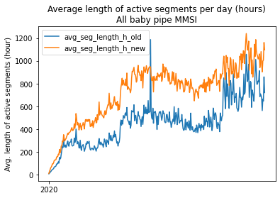

```python
fig = plot_new_vs_old(df_segs_daily, col_prefix='avg_seg_length_h_',
                      title="Average length of active segments per day (hours)\nAll baby pipe MMSI",
                      ylabel="Avg. length of active segments (hour)")
```

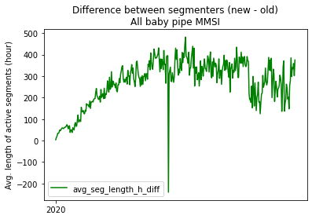

```python
fig = plot_diff(df_segs_daily, col_prefix='avg_seg_length_h_',
                title="Difference between segmenters (new - old)\nAll baby pipe MMSI",
                ylabel="Avg. length of active segments (hour)")
```

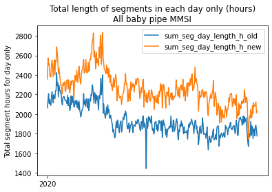

```python
fig = plot_new_vs_old(df_segs_daily, col_prefix='sum_seg_day_length_h_',
                      title="Total length of segments in each day only (hours)\nAll baby pipe MMSI",
                      ylabel="Total segment hours for day only")
```

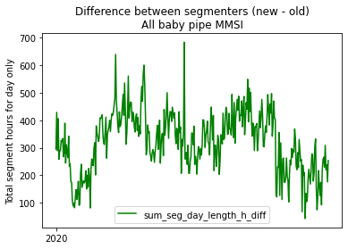

```python
fig = plot_diff(df_segs_daily, col_prefix='sum_seg_day_length_h_',
                title="Difference between segmenters (new - old)\nAll baby pipe MMSI",
                ylabel="Total segment hours for day only")
```

## MMSI with biggest changes

```python
q = f'''
WITH

seg_hours_new AS (
  SELECT
    ssvid,
    seg_id,
    TIMESTAMP_DIFF(last_timestamp, first_timestamp, MINUTE)/60.0 as hours
  FROM `{DATASET_NEW_MONTHLY_INT}.{SEGMENT_INFO_TABLE}`
),

seg_hours_old AS (
  SELECT
    ssvid,
    seg_id,
    TIMESTAMP_DIFF(
        IF(last_timestamp <= '2020-12-31 23:59:59', last_timestamp, TIMESTAMP('2020-12-31 23:59:59')),
        IF(first_timestamp >= '2020-01-01', first_timestamp, TIMESTAMP('2020-01-01'))
        , MINUTE)/60.0 as hours
  FROM `{DATASET_OLD}.{SEGMENT_INFO_TABLE}`
  WHERE (DATE(first_timestamp) <= '2020-12-31' AND DATE(last_timestamp) >= '2020-01-01')
  AND (ssvid IN (SELECT DISTINCT ssvid FROM `{DATASET_NEW_MONTHLY_INT}.{SEGMENT_INFO_TABLE}`))
),

ssvid_stats_new AS (
  SELECT
    ssvid,
    COUNT(*) as num_segs_new,
    COUNT(DISTINCT seg_id) as num_segs_distinct_new,
    SUM(hours) as sum_seg_length_h_new,
    SUM(hours) / COUNT(*) as avg_seg_length_h_new
  FROM seg_hours_new
  GROUP BY ssvid
),

ssvid_stats_old AS (
  SELECT
    ssvid,
    COUNT(*) as num_segs_old,
    COUNT(DISTINCT seg_id) as num_segs_distinct_old,
    SUM(hours) as sum_seg_length_h_old,
    SUM(hours) / COUNT(*) as avg_seg_length_h_old
  FROM seg_hours_old
  GROUP BY ssvid
)

SELECT *,
num_segs_new - num_segs_old AS num_segs_diff,
num_segs_distinct_new - num_segs_distinct_old AS num_segs_distinct_diff,
sum_seg_length_h_new - sum_seg_length_h_old AS sum_seg_length_h_diff,
avg_seg_length_h_new - avg_seg_length_h_old AS avg_seg_length_h_diff,
ABS(num_segs_new - num_segs_old) AS num_segs_diff_abs,
ABS(num_segs_distinct_new - num_segs_distinct_old) AS num_segs_distinct_diff_abs,
ABS(sum_seg_length_h_new - sum_seg_length_h_old) AS sum_seg_length_h_diff_abs,
ABS(avg_seg_length_h_new - avg_seg_length_h_old) AS avg_seg_length_h_diff_abs,
FROM ssvid_stats_new
FULL OUTER JOIN ssvid_stats_old
USING(ssvid)
'''
# print(q)
df_ssvid_stats = pd.read_gbq(q, project_id='world-fishing-827', dialect='standard')
```

#### Summary of changes

The overwhelming majority of the drop in the number of segments occurs for `413000000`. The decrease in the number of segments is smaller for the rest of the MMSI but the majority of MMSI have a decrease in segments.

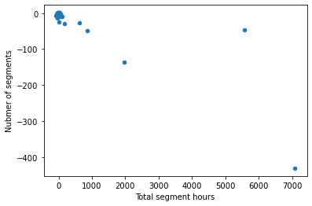

```python
df_ssvid_stats[df_ssvid_stats.ssvid != '413000000'].plot.scatter(
        x="sum_seg_length_h_diff",
        y="num_segs_distinct_diff")
plt.xlabel("Total segment hours")
plt.ylabel("Nubmer of segments")
plt.show()
```

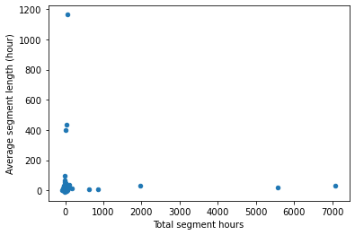

```python
df_ssvid_stats[df_ssvid_stats.ssvid != '413000000'].plot.scatter(
        x="sum_seg_length_h_diff",
        y="avg_seg_length_h_diff")
plt.xlabel("Total segment hours")
plt.ylabel("Average segment length (hour)")
plt.show()
```

#### Number of segments

```python
df_ssvid_stats.sort_values("num_segs_distinct_diff_abs", ascending=False)[:10][['ssvid', 'num_segs_distinct_new', 'num_segs_distinct_old', 'num_segs_distinct_diff', 'num_segs_distinct_diff_abs']].reset_index(drop=True)
```

|  | ssvid | num_segs_distinct_new | num_segs_distinct_old | num_segs_distinct_diff | num_segs_distinct_diff_abs |
| --- | --- | --- | --- | --- | --- |
| 0 | 413000000 | 6844 | 50887 | -44043 | 44043 |
| 1 | 100900000 | 775 | 1206 | -431 | 431 |
| 2 | 567000000 | 292 | 428 | -136 | 136 |
| 3 | 271055001 | 297 | 345 | -48 | 48 |
| 4 | 666000001 | 395 | 442 | -47 | 47 |
| 5 | 416245700 | 151 | 180 | -29 | 29 |
| 6 | 244453043 | 143 | 170 | -27 | 27 |
| 7 | 636019687 | 53 | 78 | -25 | 25 |
| 8 | 224306000 | 54 | 67 | -13 | 13 |
| 9 | 565382000 | 27 | 39 | -12 | 12 |

#### Total segment hours

```python
df_ssvid_stats.sort_values("sum_seg_length_h_diff_abs", ascending=False)[:10][['ssvid', 'sum_seg_length_h_new', 'sum_seg_length_h_old', 'sum_seg_length_h_diff', 'sum_seg_length_h_diff_abs', 'num_segs_distinct_new', 'num_segs_distinct_old', 'num_segs_distinct_diff', 'num_segs_distinct_diff_abs']].reset_index(drop=True)
```

|  | ssvid | sum_seg_length_h_new | sum_seg_length_h_old | sum_seg_length_h_diff | sum_seg_length_h_diff_abs | num_segs_distinct_new | num_segs_distinct_old | num_segs_distinct_diff | num_segs_distinct_diff_abs |
| --- | --- | --- | --- | --- | --- | --- | --- | --- | --- |
| 0 | 413000000 | 463400.783333 | 86152.633333 | 377248.150000 | 377248.150000 | 6844 | 50887 | -44043 | 44043 |
| 1 | 100900000 | 51555.033333 | 44466.250000 | 7088.783333 | 7088.783333 | 775 | 1206 | -431 | 431 |
| 2 | 666000001 | 27010.450000 | 21433.683333 | 5576.766667 | 5576.766667 | 395 | 442 | -47 | 47 |
| 3 | 567000000 | 22060.333333 | 20097.150000 | 1963.183333 | 1963.183333 | 292 | 428 | -136 | 136 |
| 4 | 271055001 | 10282.833333 | 9421.816667 | 861.016667 | 861.016667 | 297 | 345 | -48 | 48 |
| 5 | 244453043 | 4285.750000 | 3654.550000 | 631.200000 | 631.200000 | 143 | 170 | -27 | 27 |
| 6 | 416245700 | 9423.966667 | 9244.850000 | 179.116667 | 179.116667 | 151 | 180 | -29 | 29 |
| 7 | 273438920 | 7949.783333 | 7834.033333 | 115.750000 | 115.750000 | 41 | 50 | -9 | 9 |
| 8 | 367776660 | 9037.683333 | 9122.633333 | -84.950000 | 84.950000 | 144 | 151 | -7 | 7 |
| 9 | 725000929 | 7041.816667 | 6965.966667 | 75.850000 | 75.850000 | 65 | 74 | -9 | 9 |

#### Average segment length (hours)

```python
df_ssvid_stats.sort_values("avg_seg_length_h_diff_abs", ascending=False)[:10][['ssvid', 'avg_seg_length_h_new', 'avg_seg_length_h_old', 'avg_seg_length_h_diff', 'avg_seg_length_h_diff_abs']].reset_index(drop=True)
```

|  | ssvid | avg_seg_length_h_new | avg_seg_length_h_old | avg_seg_length_h_diff | avg_seg_length_h_diff_abs |
| --- | --- | --- | --- | --- | --- |
| 0 | 244020394 | 2887.644444 | 1722.830000 | 1164.814444 | 1164.814444 |
| 1 | 229000611 | 2153.312500 | 1717.796667 | 435.515833 | 435.515833 |
| 2 | 237352400 | 1399.083333 | 999.359524 | 399.723810 | 399.723810 |
| 3 | 565382000 | 320.167284 | 222.122650 | 98.044634 | 98.044634 |
| 4 | 520318000 | 415.976190 | 349.548667 | 66.427524 | 66.427524 |
| 5 | 413000000 | 67.709057 | 1.693019 | 66.016038 | 66.016038 |
| 6 | 412420375 | 729.625000 | 673.555128 | 56.069872 | 56.069872 |
| 7 | 636019687 | 153.153459 | 103.820940 | 49.332519 | 49.332519 |
| 8 | 416004378 | 318.790909 | 280.616000 | 38.174909 | 38.174909 |
| 9 | 273438920 | 193.897154 | 156.680667 | 37.216488 | 37.216488 |

## Daily patterns of 413000000

`413000000` generally dominates the overall pattern so it is interesting to see that and to see what the pattern looks like without `413000000`

### The difference in the number of segments and hours of all MMSI vs just `413000000`

To confirm that `413000000` dominates the pattern. This may not be true for future QA and your copy of this notebook may need to be modified to look deeper.

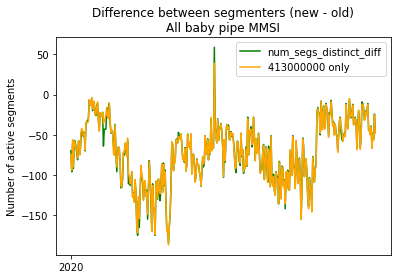

```python
fig, ax = plot_diff(df_segs_daily, col_prefix='num_segs_distinct_',
                title="Difference between segmenters (new - old)\nAll baby pipe MMSI",
                ylabel="Number of active segments")
df_temp = df_segs_daily_by_ssvid[df_segs_daily_by_ssvid.ssvid == '413000000'].copy().reset_index(drop=True)
df_temp.num_segs_distinct_diff.plot(c='orange', ax=ax, label='413000000 only')
plt.legend()
plt.show()
```

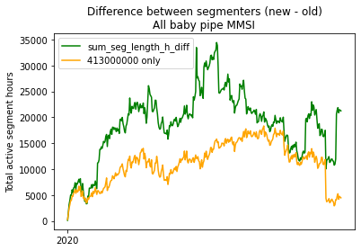

```python
fig, ax = plot_diff(df_segs_daily, col_prefix='sum_seg_length_h_',
                title="Difference between segmenters (new - old)\nAll baby pipe MMSI",
                ylabel="Total active segment hours")
df_temp = df_segs_daily_by_ssvid[df_segs_daily_by_ssvid.ssvid == '413000000'].copy().reset_index(drop=True)
df_temp.sum_seg_length_h_diff.plot(c='orange', ax=ax, label='413000000 only')
plt.legend()
plt.show()
```

## Daily Stats WITHOUT `413000000`

```python
df_segs_daily_no_413000000 = make_daily(df_segs_daily_by_ssvid[df_segs_daily_by_ssvid.ssvid != '413000000'])
```

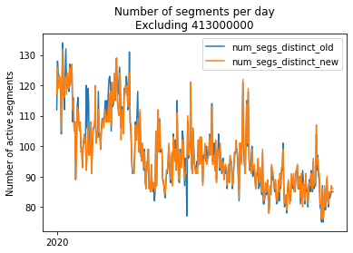

```python
fig = plot_new_vs_old(df_segs_daily_no_413000000, col_prefix='num_segs_distinct_',
                      title="Number of segments per day\nExcluding 413000000",
                      ylabel="Number of active segments")
```

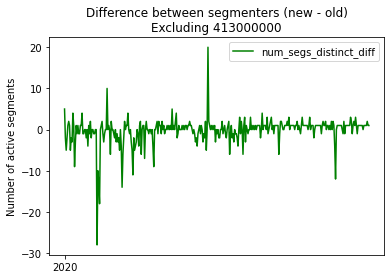

```python
fig = plot_diff(df_segs_daily_no_413000000, col_prefix='num_segs_distinct_',
                title="Difference between segmenters (new - old)\nExcluding 413000000",
                ylabel="Number of active segments")
```

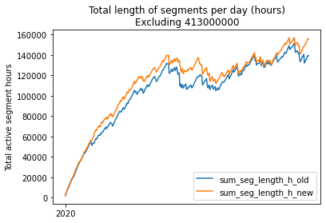

```python
fig = plot_new_vs_old(df_segs_daily_no_413000000, col_prefix='sum_seg_length_h_',
                      title="Total length of segments per day (hours)\nExcluding 413000000",
                      ylabel="Total active segment hours")
```

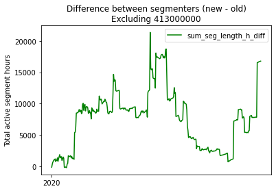

```python
fig = plot_diff(df_segs_daily_no_413000000, col_prefix='sum_seg_length_h_',
                title="Difference between segmenters (new - old)\nExcluding 413000000",
                ylabel="Total active segment hours")
```

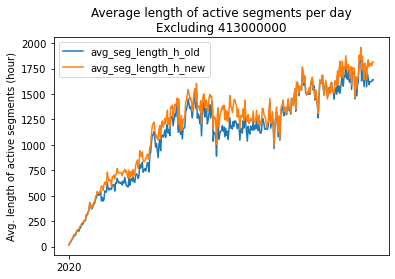

```python
fig = plot_new_vs_old(df_segs_daily_no_413000000, col_prefix='avg_seg_length_h_',
                      title="Average length of active segments per day\nExcluding 413000000",
                      ylabel="Avg. length of active segments (hour)")
```

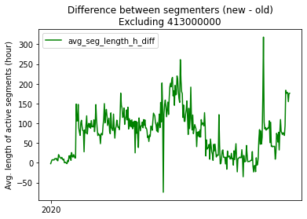

```python
fig = plot_diff(df_segs_daily_no_413000000, col_prefix='avg_seg_length_h_',
                title="Difference between segmenters (new - old)\nExcluding 413000000",
                ylabel="Avg. length of active segments (hour)")
```

[figure not shown]

```python
fig = plot_new_vs_old(df_segs_daily_no_413000000, col_prefix='sum_seg_day_length_h_',
                      title="Total length of segments in each day only (hours)\nAll baby pipe MMSI",
                      ylabel="Total segment hours for day only")
```

[figure not shown]

```python
fig = plot_diff(df_segs_daily_no_413000000, col_prefix='sum_seg_day_length_h_',
                title="Difference between segmenters (new - old)\nAll baby pipe MMSI",
                ylabel="Total segment hours for day only")
```

## Overall segment Stats

Calculated at the segment level for the set of final segments in 2020. Segment lengths for the old dataset are truncated as starting on '2020-01-01' for comparability.

```python
q = f'''
WITH

seg_hours_new AS (
  SELECT
    seg_id,
    TIMESTAMP_DIFF(last_timestamp, first_timestamp, MINUTE)/60.0 as hours
  FROM `{DATASET_NEW_MONTHLY_INT}.{SEGMENT_INFO_TABLE}`
),

seg_hours_no_413000000_new AS (
  SELECT
    seg_id,
    TIMESTAMP_DIFF(last_timestamp, first_timestamp, MINUTE)/60.0 as hours
  FROM `{DATASET_NEW_MONTHLY_INT}.{SEGMENT_INFO_TABLE}`
  WHERE ssvid != '413000000'
),

seg_hours_old AS (
  SELECT
    seg_id,
    TIMESTAMP_DIFF(
        IF(last_timestamp <= '2020-12-31 23:59:59', last_timestamp, TIMESTAMP('2020-12-31 23:59:59')),
        IF(first_timestamp >= '2020-01-01', first_timestamp, TIMESTAMP('2020-01-01'))
        , MINUTE)/60.0 as hours
  FROM `{DATASET_OLD}.{SEGMENT_INFO_TABLE}`
  WHERE (DATE(first_timestamp) <= '2020-12-31' AND DATE(last_timestamp) >= '2020-01-01')
  AND (ssvid IN (SELECT DISTINCT ssvid FROM `{DATASET_NEW_MONTHLY_INT}.{SEGMENT_INFO_TABLE}`))
),

seg_hours_no_413000000_old AS (
  SELECT
    seg_id,
    TIMESTAMP_DIFF(
        IF(last_timestamp <= '2020-12-31 23:59:59', last_timestamp, TIMESTAMP('2020-12-31 23:59:59')),
        IF(first_timestamp >= '2020-01-01', first_timestamp, TIMESTAMP('2020-01-01'))
        , MINUTE)/60.0 as hours
  FROM `{DATASET_OLD}.{SEGMENT_INFO_TABLE}`
  WHERE (DATE(first_timestamp) <= '2020-12-31' AND DATE(last_timestamp) >= '2020-01-01')
  AND (ssvid IN (SELECT DISTINCT ssvid FROM `{DATASET_NEW_MONTHLY_INT}.{SEGMENT_INFO_TABLE}`))
  AND ssvid != '413000000'
),

all_mmsi_stats AS (
SELECT 'all mmsi' as description, * EXCEPT (jn)
FROM
(
  SELECT
    1 as jn,
    COUNT(*) as num_segs_new,
    COUNT(DISTINCT seg_id) as num_segs_distinct_new,
    SUM(hours) as sum_seg_length_h_new,
    SUM(hours)/COUNT(*) as avg_hours_new
  FROM seg_hours_new
)
JOIN
(
  SELECT
    1 as jn,
    COUNT(*) as num_segs_old,
    COUNT(DISTINCT seg_id) as num_segs_distinct_old,
    SUM(hours) as sum_seg_length_h_old,
    SUM(hours)/COUNT(*) as avg_hours_old
  FROM seg_hours_old
)
USING (jn)
),

no_413000000_stats AS (
  SELECT 'no 413000000' as description, * EXCEPT (jn)
FROM
(
  SELECT
    1 as jn,
    COUNT(*) as num_segs_new,
    COUNT(DISTINCT seg_id) as num_segs_distinct_new,
    SUM(hours) as sum_seg_length_h_new,
    SUM(hours)/COUNT(*) as avg_hours_new
  FROM seg_hours_no_413000000_new
)
JOIN
(
  SELECT
    1 as jn,
    COUNT(*) as num_segs_old,
    COUNT(DISTINCT seg_id) as num_segs_distinct_old,
    SUM(hours) as sum_seg_length_h_old,
    SUM(hours)/COUNT(*) as avg_hours_old
  FROM seg_hours_no_413000000_old
)
USING (jn)
)

(SELECT * FROM all_mmsi_stats)
UNION ALL
(SELECT * FROM no_413000000_stats)
ORDER BY description
'''

# print(q)
df_seg_stats = pd.read_gbq(q, project_id='world-fishing-827', dialect='standard')
```

```python
df_seg_stats_all_mmsi = df_seg_stats[df_seg_stats.description == 'all mmsi'].copy().iloc[0]
df_seg_stats_no_413000000 = df_seg_stats[df_seg_stats.description == 'no 413000000'].copy().iloc[0]
```

```python
print("STATS FOR ALL MMSI")
print("--------------------")
print(f"Num distinct segs (NEW):  {df_seg_stats_all_mmsi.num_segs_distinct_new}")
print(f"Num distinct segs (OLD):  {df_seg_stats_all_mmsi.num_segs_distinct_old}")
print(f"Num distinct segs (DIFF): {df_seg_stats_all_mmsi.num_segs_distinct_new - df_seg_stats_all_mmsi.num_segs_distinct_old}")
print()
print(f"Sum seg hours (NEW):  {round(df_seg_stats_all_mmsi.sum_seg_length_h_new):,d}")
print(f"Sum seg hours (OLD):  {round(df_seg_stats_all_mmsi.sum_seg_length_h_old):,d}")
print(f"Sum seg hours (DIFF): {round(df_seg_stats_all_mmsi.sum_seg_length_h_new - df_seg_stats_all_mmsi.sum_seg_length_h_old):,d}")
print()
print(f"Avg seg length (NEW): {df_seg_stats_all_mmsi.avg_hours_new:0.2f}")
print(f"Avg seg length (OLD): {df_seg_stats_all_mmsi.avg_hours_old:0.2f}")
print(f"Avg seg length (DIFF): {df_seg_stats_all_mmsi.avg_hours_new - df_seg_stats_all_mmsi.avg_hours_old:0.2f}")
```

```
STATS FOR ALL MMSI
--------------------
Num distinct segs (NEW):  12959
Num distinct segs (OLD):  57920
Num distinct segs (DIFF): -44961

Sum seg hours (NEW):  1,175,264
Sum seg hours (OLD):  781,371
Sum seg hours (DIFF): 393,893

Avg seg length (NEW): 90.69
Avg seg length (OLD): 13.49
Avg seg length (DIFF): 77.20
```

```python
print("STATS WITHOUT 413000000")
print("--------------------")
print(f"Num distinct segs (NEW):  {df_seg_stats_no_413000000.num_segs_distinct_new}")
print(f"Num distinct segs (OLD):  {df_seg_stats_no_413000000.num_segs_distinct_old}")
print(f"Num distinct segs (DIFF): {df_seg_stats_no_413000000.num_segs_distinct_new - df_seg_stats_no_413000000.num_segs_distinct_old}")
print()
print(f"Sum seg hours (NEW):  {round(df_seg_stats_no_413000000.sum_seg_length_h_new):,d}")
print(f"Sum seg hours (OLD):  {round(df_seg_stats_no_413000000.sum_seg_length_h_old):,d}")
print(f"Sum seg hours (DIFF): {round(df_seg_stats_no_413000000.sum_seg_length_h_new - df_seg_stats_no_413000000.sum_seg_length_h_old):,d}")
print()
print(f"Avg seg length (NEW): {df_seg_stats_no_413000000.avg_hours_new:0.2f}")
print(f"Avg seg length (OLD): {df_seg_stats_no_413000000.avg_hours_old:0.2f}")
print(f"Avg seg length (DIFF): {df_seg_stats_no_413000000.avg_hours_new - df_seg_stats_no_413000000.avg_hours_old:0.2f}")
```

```
STATS WITHOUT 413000000
--------------------
Num distinct segs (NEW):  6115
Num distinct segs (OLD):  7033
Num distinct segs (DIFF): -918

Sum seg hours (NEW):  711,863
Sum seg hours (OLD):  695,219
Sum seg hours (DIFF): 16,644

Avg seg length (NEW): 116.41
Avg seg length (OLD): 98.85
Avg seg length (DIFF): 17.56
```

# Code for pulling tracks, as needed

If you need to investigate particular MMSI, you can plot in this notebook using pyseas and/or you can download a CSV of tracks to upload to the Global Fishing Watch online map. For very spoofy MMSI or for long periods of time, the map may be a better option as pyseas will struggle or fail to render too many segments. Also if there are a lot of segments, be sure to set `plot_legend` to False as rendering a long list of segment names will cause it to slow down significantly or fail.

#### Plot with `pyseas`

```python
def get_tracks(dataset, ssvid, start_date, end_date):
    '''
    Retrieve the tracks for a given MMSI over a given date range in
    the form of AIS messages with lat, lon, timestamp, and seg_id to
    allow for plotting.

    Args:
        dataset: string representing BigQuery dataset containing messages_segmented table
        ssvid: MMSI for the vessel of interest
        start_date: first date to consider for tracks in format "YYYYMMDD"
        end_date: last date to consider for tracks in format "YYYYMMDD"

    Returns:
        dataframe of tracks
    '''
    q = f'''
    SELECT
    ssvid, timestamp, lat, lon, seg_id
    FROM `{dataset}.{MESSAGES_SEGMENTED_TABLE}*`
    WHERE ssvid = '{ssvid}'
    AND _TABLE_SUFFIX BETWEEN '{start_date}' AND '{end_date}'
    AND seg_id IS NOT NULL
    ORDER BY timestamp
    '''

    # print(q)
    return pd.read_gbq(q, project_id='world-fishing-827', dialect='standard')
```

```python
def get_segments(dataset, ssvid, start_date, end_date):
    '''
    Retrieve the segments for a given MMSI betwee a given date range.

    Args:
        dataset: string representing BigQuery dataset containing segment_info table
        ssvid: MMSI for the vessel of interest
        start_date: first date to consider for tracks in format "YYYY-MM-DD"
        end_date: last date to consider for tracks in format "YYYY-MM-DD"

    Returns:
        dataframe of segments
    '''
    q = f'''
    SELECT
    *
    FROM `{dataset}.{SEGMENT_INFO_TABLE}*`
    WHERE ssvid = '{ssvid}'
    AND (DATE(first_timestamp) <= '{end_date}' AND DATE(last_timestamp) >= '{start_date}')
    ORDER BY seg_id
    '''

    # print(q)
    return pd.read_gbq(q, project_id='world-fishing-827', dialect='standard')
```

```python
def plot_segmented_tracks(df, plot_legend=True):
    '''
    Plot tracks on a map with different segments divided by color.

    Args:
        df: dataframe containing tracks to plot, requires lat, lon, timestamp, and seg_id
        plot_legend: if legend should be added (default=True)

    Returns:
        matplotlib figure
    '''
    with psm.context(psm.styles.panel):
        fig = plt.figure(figsize=(12, 12))
        info = psc.multi_track_panel(
            df.timestamp,
            df.lon,
            df.lat,
            df.seg_id,
            plots=[{"label": "lon", "values": df.lon}, {"label": "lat", "values": df.lat}],
        )
        if plot_legend:
            plt.legend(
                info.legend_handles.values(),
                [x.split("-", 1)[1].rstrip(".000000000Z") for x in info.legend_handles.keys()],
            )
        return fig
```

##### Step 1: Explore segments to chose dates to pull tracks

```python
ssvid_1 = '538004933'
segs_1 = get_segments(DATASET_NEW_MONTHLY_INT, ssvid_1, '2020-01-01', '2020-12-31')
```

```python
segs_1
```

|  | vessel_id | seg_id | ssvid | first_timestamp | last_timestamp | msg_count | pos_count | ident_count | noise | shipname | callsign | imo | n_shipname | n_callsign | n_imo | shiptype | length | width |
| --- | --- | --- | --- | --- | --- | --- | --- | --- | --- | --- | --- | --- | --- | --- | --- | --- | --- | --- |
| 0 | 386e7dc33-3699-f921-2f48-56ce5ff330f2 | 538004933-2020-01-01T00:03:53.000000Z-1 | 538004933 | 2020-01-01 00:03:53+00:00 | 2020-01-12 20:36:44+00:00 | 21570 | 4562 | 17008 | False | {'value': 'NAVIN RAVEN', 'count': 17008, 'freq... | {'value': 'V7ZW9', 'count': 17008, 'freq': 1.0} | {'value': '9368649', 'count': 17008, 'freq': 1.0} | {'value': 'NAVINRAVEN', 'count': 17008, 'freq'... | {'value': 'V7ZW9', 'count': 17008, 'freq': 1.0} | {'value': '9368649', 'count': 17008, 'freq': 1.0} | None | {'value': '121.0', 'count': 17008, 'freq': 1.0} | {'value': '17.0', 'count': 17008, 'freq': 1.0} |
| 1 | 386e7dc33-3699-f921-2f48-56ce5ff330f2 | 538004933-2020-01-11T05:07:47.000000Z-1 | 538004933 | 2020-01-11 05:07:47+00:00 | 2020-01-11 05:07:47+00:00 | 1 | 1 | 0 | False | None | None | None | None | None | None | None | None | None |
| 2 | 386e7dc33-3699-f921-2f48-56ce5ff330f2 | 538004933-2020-01-12T09:29:45.000000Z-1 | 538004933 | 2020-01-12 09:29:45+00:00 | 2020-01-12 09:29:45+00:00 | 1 | 1 | 0 | False | None | None | None | None | None | None | None | None | None |
| 3 | 386e7dc33-3699-f921-2f48-56ce5ff330f2 | 538004933-2020-01-13T23:49:52.000000Z-1 | 538004933 | 2020-01-13 23:49:52+00:00 | 2020-01-25 19:59:05+00:00 | 16396 | 3569 | 12827 | False | {'value': 'NAVIN RAVEN', 'count': 12827, 'freq... | {'value': 'V7ZW9', 'count': 12827, 'freq': 1.0} | {'value': '9368649', 'count': 12827, 'freq': 1.0} | {'value': 'NAVINRAVEN', 'count': 12827, 'freq'... | {'value': 'V7ZW9', 'count': 12827, 'freq': 1.0} | {'value': '9368649', 'count': 12827, 'freq': 1.0} | None | {'value': '121.0', 'count': 12827, 'freq': 1.0} | {'value': '17.0', 'count': 12827, 'freq': 1.0} |
| 4 | 386e7dc33-3699-f921-2f48-56ce5ff330f2 | 538004933-2020-01-14T03:40:34.000000Z-1 | 538004933 | 2020-01-14 03:40:34+00:00 | 2020-01-14 03:40:34+00:00 | 1 | 1 | 0 | False | None | None | None | None | None | None | None | None | None |
| ... | ... | ... | ... | ... | ... | ... | ... | ... | ... | ... | ... | ... | ... | ... | ... | ... | ... | ... |
| 19 | 386e7dc33-3699-f921-2f48-56ce5ff330f2 | 538004933-2020-08-10T07:11:13.000000Z-1 | 538004933 | 2020-08-10 07:11:13+00:00 | 2020-09-01 15:55:04+00:00 | 8349 | 3513 | 4836 | False | {'value': 'NAVIN RAVEN', 'count': 4836, 'freq'... | {'value': 'V7ZW9', 'count': 4836, 'freq': 1.0} | {'value': '9368649', 'count': 4836, 'freq': 1.0} | {'value': 'NAVINRAVEN', 'count': 4836, 'freq':... | {'value': 'V7ZW9', 'count': 4836, 'freq': 1.0} | {'value': '9368649', 'count': 4836, 'freq': 1.0} | None | {'value': '121.0', 'count': 4836, 'freq': 1.0} | {'value': '17.0', 'count': 4836, 'freq': 1.0} |
| 20 | 386e7dc33-3699-f921-2f48-56ce5ff330f2 | 538004933-2020-09-03T02:47:39.000000Z-1 | 538004933 | 2020-09-03 02:47:39+00:00 | 2020-09-20 19:28:26+00:00 | 11060 | 3397 | 7663 | False | {'value': 'NAVIN RAVEN', 'count': 7663, 'freq'... | {'value': 'V7ZW9', 'count': 7663, 'freq': 1.0} | {'value': '9368649', 'count': 7663, 'freq': 1.0} | {'value': 'NAVINRAVEN', 'count': 7663, 'freq':... | {'value': 'V7ZW9', 'count': 7663, 'freq': 1.0} | {'value': '9368649', 'count': 7663, 'freq': 1.0} | None | {'value': '121.0', 'count': 7663, 'freq': 1.0} | {'value': '17.0', 'count': 7663, 'freq': 1.0} |
| 21 | 386e7dc33-3699-f921-2f48-56ce5ff330f2 | 538004933-2020-09-27T17:09:06.000000Z-1 | 538004933 | 2020-09-27 17:09:06+00:00 | 2020-09-29 02:52:38+00:00 | 28 | 26 | 2 | False | {'value': 'NAVIN RAVEN', 'count': 2, 'freq': 1.0} | {'value': 'V7ZW9', 'count': 2, 'freq': 1.0} | {'value': '9368649', 'count': 2, 'freq': 1.0} | {'value': 'NAVINRAVEN', 'count': 2, 'freq': 1.0} | {'value': 'V7ZW9', 'count': 2, 'freq': 1.0} | {'value': '9368649', 'count': 2, 'freq': 1.0} | None | {'value': '121.0', 'count': 2, 'freq': 1.0} | {'value': '17.0', 'count': 2, 'freq': 1.0} |
| 22 | 386e7dc33-3699-f921-2f48-56ce5ff330f2 | 538004933-2020-09-30T20:59:58.000000Z-1 | 538004933 | 2020-09-30 20:59:58+00:00 | 2020-10-09 19:19:51+00:00 | 3532 | 1428 | 2104 | False | {'value': 'NAVIN RAVEN', 'count': 2104, 'freq'... | {'value': 'V7ZW9', 'count': 2104, 'freq': 1.0} | {'value': '9368649', 'count': 2104, 'freq': 1.0} | {'value': 'NAVINRAVEN', 'count': 2104, 'freq':... | {'value': 'V7ZW9', 'count': 2104, 'freq': 1.0} | {'value': '9368649', 'count': 2104, 'freq': 1.0} | None | {'value': '121.0', 'count': 2082, 'freq': 0.98... | {'value': '17.0', 'count': 2082, 'freq': 0.989... |
| 23 | 386e7dc33-3699-f921-2f48-56ce5ff330f2 | 538004933-2020-10-12T13:36:48.000000Z-1 | 538004933 | 2020-10-12 13:36:48+00:00 | 2020-12-31 23:51:41+00:00 | 150030 | 34200 | 115830 | False | {'value': 'NAVIN RAVEN', 'count': 115830, 'fre... | {'value': 'V7ZW9', 'count': 115830, 'freq': 1.0} | {'value': '9368649', 'count': 115830, 'freq': ... | {'value': 'NAVINRAVEN', 'count': 115830, 'freq... | {'value': 'V7ZW9', 'count': 115830, 'freq': 1.0} | {'value': '9368649', 'count': 115830, 'freq': ... | None | {'value': '121.0', 'count': 115813, 'freq': 0.... | {'value': '17.0', 'count': 115813, 'freq': 0.9... |

24 rows × 18 columns

##### Pull and plot tracks

```python
start_date_1 = '20200101'
end_date_1 = '2020112'
tracks1_new = get_tracks(DATASET_NEW_MONTHLY_INT, ssvid_1, start_date_1, end_date_1)
tracks1_old = get_tracks(DATASET_OLD, ssvid_1, start_date_1, end_date_1)
```

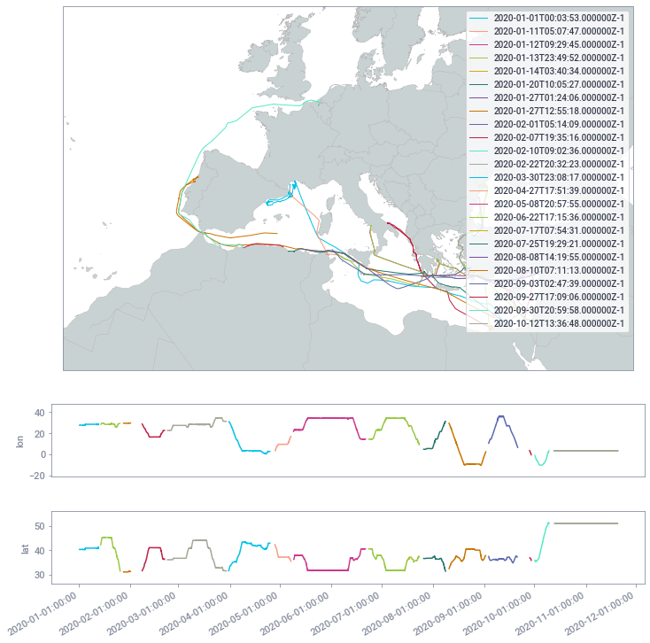

```python
fig = plot_segmented_tracks(tracks1_new)
```

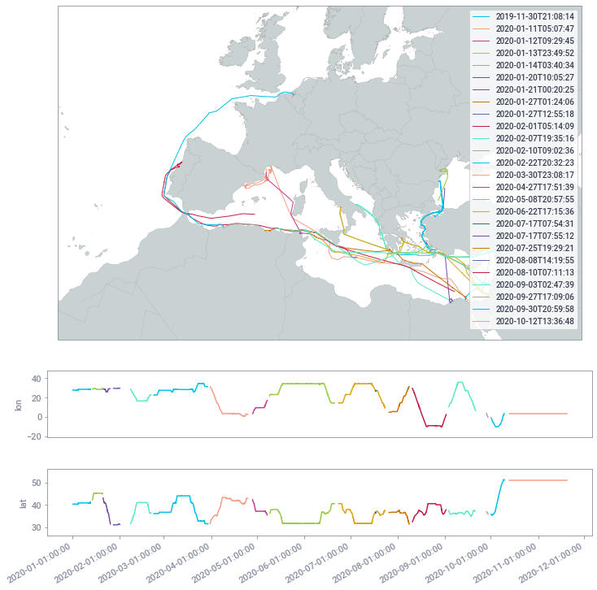

```python
fig = plot_segmented_tracks(tracks1_old)
```

##### `413000000` example of tracks

```python
tracks_413000000_new = get_tracks(DATASET_NEW_MONTHLY_INT, '413000000', '20200102', '20200102')
tracks_413000000_old = get_tracks(DATASET_OLD, '413000000', '20200102', '20200102')
```

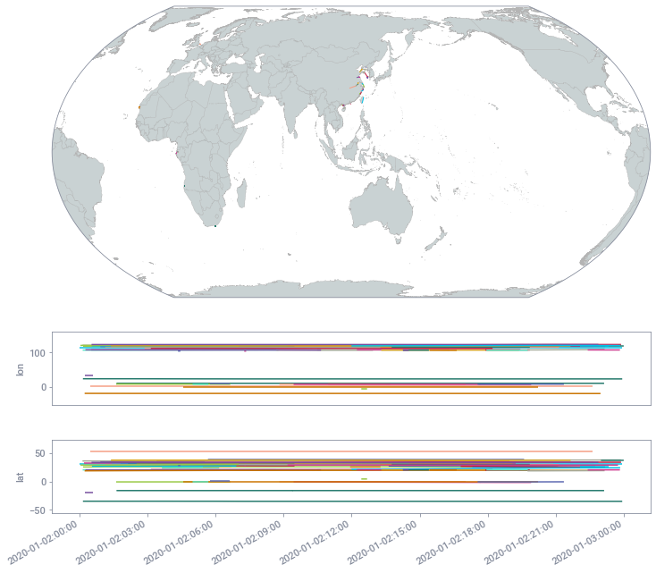

```python
fig = plot_segmented_tracks(tracks_413000000_new, plot_legend=False)
```

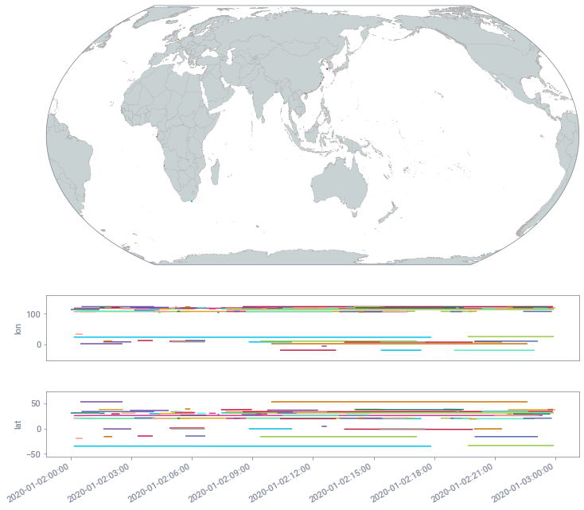

```python
fig = plot_segmented_tracks(tracks_413000000_old, plot_legend=False)
```

#### Output CSV for use with GFW map

These CSV can be uploaded in the GFW map (https://globalfishingwatch.org/map) in the `Environments` section.

```python
data_folder = 'data'
if not os.path.exists(data_folder):
    os.makedirs(data_folder)
```

```python
tracks1_new.to_csv(f'{data_folder}/tracks_{ssvid_1}_new.csv')
tracks1_old.to_csv(f'{data_folder}/tracks_{ssvid_1}_old.csv')
```